# Claude로 하는 Text to SQL

## 들어가며

Text to SQL은 사람이 읽을 수 있는 텍스트 질의를 구조화된 SQL 질의로 바꾸는 자연어 처리 작업입니다. 덕분에 사용자가 자연어로 데이터베이스와 상호작용할 수 있습니다.

Claude는 맥락을 이해하고, 복잡한 질의를 해석하고, 정확한 SQL 문을 생성할 수 있습니다. 이 가이드는 Claude로 견고한 Text to SQL 시스템을 만드는 데 초점을 맞춥니다.

## Text to SQL은 왜 유용한가?

Text to SQL이 가치 있는 이유는 여러 가지입니다.

1. **접근성**: 기술 배경이 없는 사용자도 SQL 문법을 몰라도 데이터베이스에 질의할 수 있어, 조직 안에서 데이터 접근이 쉬워집니다.
2. **효율성**: 데이터 분석가와 과학자가 자연어로 질의를 빠르게 시제품처럼 만들어 볼 수 있습니다.
3. **통합**: 애플리케이션과 챗봇에서 데이터베이스와 상호작용하는 더 직관적인 인터페이스를 만들 수 있습니다.
4. **복잡한 질의 생성**: LLM은 여러 조인, 서브쿼리, 집계가 얽힌 복잡한 SQL 질의를 생성할 수 있는데, 사람이 직접 쓰려면 시간이 많이 걸리는 작업입니다.

## 이 가이드가 다루는 것

이 가이드에서는 LLM으로 Text to SQL 시스템을 만들어 봅니다. 다루는 내용은 다음과 같습니다.

1. 테스트용 SQLite 데이터베이스 준비
2. Text to SQL 변환을 위한 효과적인 프롬프팅
3. 더 복잡한 데이터베이스 시스템을 다루기 위한 RAG(검색 증강 생성)
4. Claude 출력의 자기 개선과 반복
5. 평가

이 가이드를 마치면 Claude로 Text to SQL 작업을 구현하고 다듬는 방법을 이해하게 되고, 이 기법들을 여러분의 프로젝트에 적용할 틀을 갖추게 됩니다.

## 목차

1. 들어가며
2. 준비
3. 기본 Text to SQL 프롬프트 만들기
4. 예시로 프롬프트 개선하기
5. 생각의 사슬 프롬프팅 사용하기
6. 복잡한 데이터베이스 스키마를 위한 RAG 구현하기
7. 질의 자기 개선 구현하기
8. 평가
9. 더 살펴볼 것과 다음 단계

## 준비

환경을 준비하고 `employees`와 `departments` 두 테이블을 담은 테스트용 SQLite 데이터베이스를 만들겠습니다. 가이드 전반에서 이 데이터베이스를 사용합니다.

```python
%pip install -q anthropic pandas voyageai matplotlib seaborn
```

```python
import os
import sqlite3

import pandas as pd
from anthropic import Anthropic
from IPython.display import display

# Set your Claude API key
os.environ["ANTHROPIC_API_KEY"] = "YOUR_ANTHROPIC_API_KEY"
os.environ["VOYAGE_API_KEY"] = "YOUR_VOYAGE_API_KEY"

# Initialize the Anthropic client
client = Anthropic()
MODEL_NAME = "claude-sonnet-4-6"

# Filepath to the SQLite database
DATABASE_PATH = "data/data.db"
```

### 테스트 데이터베이스 만들기

```python
import random
from datetime import datetime, timedelta

if not os.path.exists(DATABASE_PATH):
    print("Database does not exist. Creating and populating...")
    # Create a new SQLite database and tables
    with sqlite3.connect(DATABASE_PATH) as conn:
        cursor = conn.cursor()

        cursor.executescript("""
        CREATE TABLE IF NOT EXISTS departments (
            id INTEGER PRIMARY KEY,
            name TEXT NOT NULL,
            location TEXT
        );
        CREATE TABLE IF NOT EXISTS employees (
            id INTEGER PRIMARY KEY,
            name TEXT NOT NULL,
            age INTEGER,
            department_id INTEGER,
            salary REAL,
            hire_date DATE,
            FOREIGN KEY (department_id) REFERENCES departments (id)
        );
        """)

        # Insert sample data
        cursor.executemany(
            "INSERT INTO departments VALUES (?,?,?)",
            [
                (1, "HR", "New York"),
                (2, "Engineering", "San Francisco"),
                (3, "Marketing", "Chicago"),
                (4, "Sales", "Los Angeles"),
                (5, "Finance", "Boston"),
                (6, "Customer Support", "Dallas"),
                (7, "Research", "Seattle"),
                (8, "Legal", "Washington D.C."),
                (9, "Product", "Austin"),
                (10, "Operations", "Denver"),
            ],
        )

        first_names = [
            "John",
            "Jane",
            "Bob",
            "Alice",
            "Charlie",
            "Diana",
            "Edward",
            "Fiona",
            "George",
            "Hannah",
            "Ian",
            "Julia",
            "Kevin",
            "Laura",
            "Michael",
            "Nora",
            "Oliver",
            "Patricia",
            "Quentin",
            "Rachel",
            "Steve",
            "Tina",
            "Ulysses",
            "Victoria",
            "William",
            "Xena",
            "Yannick",
            "Zoe",
        ]
        last_names = [
            "Smith",
            "Johnson",
            "Williams",
            "Jones",
            "Brown",
            "Davis",
            "Miller",
            "Wilson",
            "Moore",
            "Taylor",
            "Anderson",
            "Thomas",
            "Jackson",
            "White",
            "Harris",
            "Martin",
            "Thompson",
            "Garcia",
            "Martinez",
            "Robinson",
            "Clark",
            "Rodriguez",
            "Lewis",
            "Lee",
            "Walker",
            "Hall",
            "Allen",
            "Young",
            "King",
        ]

        employees_data = []
        for i in range(1, 201):  # Generate 200 employees
            name = f"{random.choice(first_names)} {random.choice(last_names)}"
            age = random.randint(22, 65)
            department_id = random.randint(1, 10)
            salary = round(random.uniform(40000, 200000), 2)
            hire_date = (datetime.now() - timedelta(days=random.randint(0, 3650))).strftime(
                "%Y-%m-%d"
            )
            employees_data.append((i, name, age, department_id, salary, hire_date))

        cursor.executemany("INSERT INTO employees VALUES (?,?,?,?,?,?)", employees_data)

    print("Database created and populated successfully.")
else:
    print("Database already exists. Skipping creation and population.")

# Display table contents
with sqlite3.connect(DATABASE_PATH) as conn:
    for table in ["departments", "employees"]:
        df = pd.read_sql_query(f"SELECT * FROM {table}", conn)
        print(f"\n{table.capitalize()} table:")
        display(df)
```

```
Database already exists. Skipping creation and population.

Departments table:
```

|  | id | name | location |
| --- | --- | --- | --- |
| 0 | 1 | HR | New York |
| 1 | 2 | Engineering | San Francisco |
| 2 | 3 | Marketing | Chicago |
| 3 | 4 | Sales | Los Angeles |
| 4 | 5 | Finance | Boston |
| 5 | 6 | Customer Support | Dallas |
| 6 | 7 | Research | Seattle |
| 7 | 8 | Legal | Washington D.C. |
| 8 | 9 | Product | Austin |
| 9 | 10 | Operations | Denver |

```
Employees table:
```

|  | id | name | age | department_id | salary | hire_date |
| --- | --- | --- | --- | --- | --- | --- |
| 0 | 1 | Michael Allen | 57 | 9 | 151012.98 | 2016-02-04 |
| 1 | 2 | Nora Hall | 23 | 8 | 186548.83 | 2018-01-27 |
| 2 | 3 | Patricia Miller | 49 | 5 | 43540.04 | 2020-06-07 |
| 3 | 4 | Alice Martinez | 48 | 7 | 131993.17 | 2021-01-21 |
| 4 | 5 | Patricia Walker | 59 | 5 | 167151.15 | 2020-05-24 |
| ... | ... | ... | ... | ... | ... | ... |
| 195 | 196 | Hannah Clark | 31 | 10 | 195944.00 | 2017-11-08 |
| 196 | 197 | Alice Davis | 46 | 5 | 145584.16 | 2022-02-13 |
| 197 | 198 | Charlie Hall | 37 | 1 | 53690.40 | 2024-06-18 |
| 198 | 199 | Alice Garcia | 50 | 5 | 92372.26 | 2024-02-01 |
| 199 | 200 | Laura Young | 25 | 9 | 64738.56 | 2015-08-02 |

200 rows × 6 columns

## 기본 Text to SQL 프롬프트 만들기

데이터베이스를 준비했으니 Text to SQL 변환을 위한 기본 프롬프트를 만들어 보겠습니다. 좋은 프롬프트에는 다음이 담겨야 합니다.

1. 모델이 무엇을 하기를 바라는지에 대한 명확한 지시
2. 사용자의 질의
3. 데이터베이스 스키마 — Claude가 사용자의 질의를 어떻게 변환할지 알 수 있도록

```python
def get_schema_info(db_path):
    conn = sqlite3.connect(db_path)
    cursor = conn.cursor()

    schema_info = []

    # Get all tables
    cursor.execute("SELECT name FROM sqlite_master WHERE type='table';")
    tables = cursor.fetchall()

    for (table_name,) in tables:
        # Get columns for this table
        cursor.execute(f"PRAGMA table_info({table_name})")
        columns = cursor.fetchall()

        table_info = f"Table: {table_name}\n"
        table_info += "\n".join(f"  - {col[1]} ({col[2]})" for col in columns)
        schema_info.append(table_info)

    conn.close()
    return "\n\n".join(schema_info)


# Get the schema info
schema = get_schema_info(DATABASE_PATH)
print(schema)
```

```
Table: departments
  - id (INTEGER)
  - name (TEXT)
  - location (TEXT)

Table: employees
  - id (INTEGER)
  - name (TEXT)
  - age (INTEGER)
  - department_id (INTEGER)
  - salary (REAL)
  - hire_date (DATE)
```

스키마 정보를 얻었으니 기본 프롬프트를 만들어 보겠습니다:

```python
def generate_prompt(schema, query):
    return f"""
        You are an AI assistant that converts natural language queries into SQL.
        Given the following SQL database schema:

        <schema>
        {schema}
        </schema>

        Convert the following natural language query into SQL:
        <query>
        {query}
        </query>

        Provide only the SQL query in your response, enclosed within <sql> tags.
    """


# Test the prompt
user_query = "What are the names of all employees in the Engineering department?"
prompt = generate_prompt(schema, user_query)
print(prompt)
```

```
        You are an AI assistant that converts natural language queries into SQL.
        Given the following SQL database schema:

        <schema>
        Table: departments
  - id (INTEGER)
  - name (TEXT)
  - location (TEXT)

Table: employees
  - id (INTEGER)
  - name (TEXT)
  - age (INTEGER)
  - department_id (INTEGER)
  - salary (REAL)
  - hire_date (DATE)
        </schema>

        Convert the following natural language query into SQL:
        <query>
        What are the names of all employees in the Engineering department?
        </query>

        Provide only the SQL query in your response, enclosed within <sql> tags.
```

이제 이 프롬프트를 Claude API와 함께 사용해 SQL을 생성해 보겠습니다:

```python
def generate_sql(prompt):
    response = client.messages.create(
        model=MODEL_NAME,
        max_tokens=1000,
        temperature=0,
        messages=[{"role": "user", "content": prompt}],
    )
    return response.content[0].text.strip()


# Generate SQL
result = generate_sql(prompt)
sql = result.split("<sql>")[1].split("</sql>")[0].strip()
print("Generated SQL:")
print(sql)
```

```
Generated SQL:
SELECT e.name
FROM employees e
JOIN departments d ON e.department_id = d.id
WHERE d.name = 'Engineering';
```

생성된 SQL을 데이터베이스에 실행해 시험해 보겠습니다:

```python
def run_sql(sql):
    conn = sqlite3.connect(DATABASE_PATH)
    result = pd.read_sql_query(sql, conn)
    conn.close()
    return result


result = run_sql(sql)
print("Query result:")
display(result)
```

```
Query result:
```

|  | name |
| --- | --- |
| 0 | Nora Lewis |
| 1 | Oliver White |
| 2 | William Clark |
| 3 | Tina Rodriguez |
| 4 | Diana Taylor |
| 5 | Nora Taylor |
| 6 | Steve Taylor |
| 7 | Oliver Martin |
| 8 | Tina Rodriguez |
| 9 | Quentin Anderson |
| 10 | Julia Miller |
| 11 | Jane Thompson |
| 12 | Julia Clark |
| 13 | Diana White |
| 14 | Xena Garcia |
| 15 | Ulysses Hall |
| 16 | Diana Brown |
| 17 | Charlie Johnson |
| 18 | Michael Clark |
| 19 | Yannick Harris |

## 예시로 프롬프트 개선하기

기본 프롬프트도 동작하지만 예시를 넣으면 더 효과적으로 만들 수 있습니다. 퓨샷 러닝이라 부르는 이 기법은 입력-출력 쌍의 구체적인 예시를 제공해 모델이 작업을 더 잘 이해하게 합니다.

`generate_prompt` 함수를 수정해 예시를 넣어 보겠습니다:

```python
def generate_prompt_with_examples(schema, query):
    examples = """
        Example 1:
        <query>List all employees in the HR department.</<query>
        <output>SELECT e.name FROM employees e JOIN departments d ON e.department_id = d.id WHERE d.name = 'HR';</output>

        Example 2:
        User: What is the average salary of employees in the Engineering department?
        SQL: SELECT AVG(e.salary) FROM employees e JOIN departments d ON e.department_id = d.id WHERE d.name = 'Engineering';

        Example 3:
        User: Who is the oldest employee?
        SQL: SELECT name, age FROM employees ORDER BY age DESC LIMIT 1;
    """

    return f"""
        You are an AI assistant that converts natural language queries into SQL.
        Given the following SQL database schema:

        <schema>
        {schema}
        </schema>

        Here are some examples of natural language queries and their corresponding SQL:

        <examples>
        {examples}
        </examples>

        Now, convert the following natural language query into SQL:
        <query>
        {query}
        </query>

        Provide only the SQL query in your response, enclosed within <sql> tags.
    """


# Test the new prompt
user_query = "What are the names and salaries of employees in the Marketing department?"
prompt = generate_prompt_with_examples(schema, user_query)
print(prompt)
```

```
        You are an AI assistant that converts natural language queries into SQL.
        Given the following SQL database schema:

        <schema>
        Table: departments
  - id (INTEGER)
  - name (TEXT)
  - location (TEXT)

Table: employees
  - id (INTEGER)
  - name (TEXT)
  - age (INTEGER)
  - department_id (INTEGER)
  - salary (REAL)
  - hire_date (DATE)
        </schema>

        Here are some examples of natural language queries and their corresponding SQL:

        <examples>

        Example 1:
        <query>List all employees in the HR department.</<query>
        <output>SELECT e.name FROM employees e JOIN departments d ON e.department_id = d.id WHERE d.name = 'HR';</output>

        Example 2:
        User: What is the average salary of employees in the Engineering department?
        SQL: SELECT AVG(e.salary) FROM employees e JOIN departments d ON e.department_id = d.id WHERE d.name = 'Engineering';

        Example 3:
        User: Who is the oldest employee?
        SQL: SELECT name, age FROM employees ORDER BY age DESC LIMIT 1;

        </examples>

        Now, convert the following natural language query into SQL:
        <query>
        What are the names and salaries of employees in the Marketing department?
        </query>

        Provide only the SQL query in your response, enclosed within <sql> tags.
```

이제 개선된 프롬프트로 SQL을 생성해 보겠습니다:

```python
# Generate SQL using the improved prompt
result = generate_sql(prompt)
sql = result.split("<sql>")[1].split("</sql>")[0].strip()
print("Generated SQL:")
print(sql)

# Run the generated SQL
result = run_sql(sql)
print("\nQuery result:")
display(result)
```

```
Generated SQL:
SELECT e.name, e.salary
FROM employees e
JOIN departments d ON e.department_id = d.id
WHERE d.name = 'Marketing';

Query result:
```

|  | name | salary |
| --- | --- | --- |
| 0 | Zoe Jones | 123511.58 |
| 1 | Jane Smith | 120291.41 |
| 2 | John Young | 179126.29 |
| 3 | Charlie King | 43323.02 |
| 4 | Jane White | 65134.81 |
| 5 | Bob Harris | 44083.34 |
| 6 | Tina Robinson | 131015.71 |
| 7 | Steve Thomas | 191563.64 |
| 8 | Laura Hall | 118691.73 |
| 9 | Fiona Young | 167114.79 |
| 10 | Bob Rodriguez | 64961.43 |
| 11 | Diana Young | 123255.78 |
| 12 | John Harris | 118778.51 |
| 13 | Edward Taylor | 112959.56 |
| 14 | Michael Thompson | 136840.04 |
| 15 | William Taylor | 49565.18 |
| 16 | Diana King | 154917.02 |
| 17 | John Davis | 46914.45 |
| 18 | Julia Garcia | 46486.44 |
| 19 | Nora Wilson | 153063.56 |

프롬프트에 예시를 넣음으로써 모델이 응답을 어떻게 구성해야 하는지 더 잘 이해하게 되었습니다. 특히 복잡한 질의에서 더 정확하고 일관된 SQL 생성으로 이어질 수 있습니다.

**참고**: 살펴볼 만한 또 다른 프롬프팅 기법은 데이터베이스 스키마에 더해 실제 데이터 몇 행을 프롬프트에 함께 넣는 것입니다. 데이터 구조와 내용에 대한 맥락을 Claude에 더 줄 수 있습니다.

다음 절에서는 더 복잡한 질의를 다루는 방법과, 생각의 사슬 프롬프팅으로 모델의 추론 과정을 개선하는 방법을 살펴봅니다.

## 생각의 사슬 프롬프팅 사용하기

생각의 사슬 프롬프팅은 모델이 복잡한 문제를 단계로 나누도록 유도합니다. Text to SQL 작업에서는 여러 연산이 필요하거나 데이터베이스 스키마를 신중히 살펴야 하는 복잡한 질의에 도움이 됩니다.

XML 태그를 사용해 생각의 사슬 추론을 넣도록 프롬프트를 수정해 보겠습니다:

```python
def generate_prompt_with_cot(schema, query):
    examples = """
    <example>
    <query>List all employees in the HR department.</query>
    <thought_process>
    1. We need to join the employees and departments tables.
    2. We'll match employees.department_id with departments.id.
    3. We'll filter for the HR department.
    4. We only need to return the employee names.
    </thought_process>
    <sql>SELECT e.name FROM employees e JOIN departments d ON e.department_id = d.id WHERE d.name = 'HR';</sql>
    </example>

    <example>
    <query>What is the average salary of employees hired in 2022?</query>
    <thought_process>
    1. We need to work with the employees table.
    2. We need to filter for employees hired in 2022.
    3. We'll use the YEAR function to extract the year from the hire_date.
    4. We'll calculate the average of the salary column for the filtered rows.
    </thought_process>
    <sql>SELECT AVG(salary) FROM employees WHERE YEAR(hire_date) = 2022;</sql>
    </example>
    """

    return f"""You are an AI assistant that converts natural language queries into SQL.
    Given the following SQL database schema:

    <schema>
    {schema}
    </schema>

    Here are some examples of natural language queries, thought processes, and their corresponding SQL:

    <examples>
    {examples}
    </examples>

    Now, convert the following natural language query into SQL:
    <query>
    {query}
    </query>

    Within <thought_process> tags, explain your thought process for creating the SQL query.
    Then, within <sql> tags, provide your output SQL query.
    """


# Test the new prompt
user_query = "What are the names and hire dates of employees in the Engineering department, ordered by their salary?"
prompt = generate_prompt_with_cot(schema, user_query)
print(prompt)
```

```
You are an AI assistant that converts natural language queries into SQL.
    Given the following SQL database schema:

    <schema>
    Table: departments
  - id (INTEGER)
  - name (TEXT)
  - location (TEXT)

Table: employees
  - id (INTEGER)
  - name (TEXT)
  - age (INTEGER)
  - department_id (INTEGER)
  - salary (REAL)
  - hire_date (DATE)
    </schema>

    Here are some examples of natural language queries, thought processes, and their corresponding SQL:

    <examples>

    <example>
    <query>List all employees in the HR department.</query>
    <thought_process>
    1. We need to join the employees and departments tables.
    2. We'll match employees.department_id with departments.id.
    3. We'll filter for the HR department.
    4. We only need to return the employee names.
    </thought_process>
    <sql>SELECT e.name FROM employees e JOIN departments d ON e.department_id = d.id WHERE d.name = 'HR';</sql>
    </example>

    <example>
    <query>What is the average salary of employees hired in 2022?</query>
    <thought_process>
    1. We need to work with the employees table.
    2. We need to filter for employees hired in 2022.
    3. We'll use the YEAR function to extract the year from the hire_date.
    4. We'll calculate the average of the salary column for the filtered rows.
    </thought_process>
    <sql>SELECT AVG(salary) FROM employees WHERE YEAR(hire_date) = 2022;</sql>
    </example>

    </examples>

    Now, convert the following natural language query into SQL:
    <query>
    What are the names and hire dates of employees in the Engineering department, ordered by their salary?
    </query>

    Within <thought_process> tags, explain your thought process for creating the SQL query.
    Then, within <sql> tags, provide your output SQL query.
```

이제 XML 태그가 포함된 생각의 사슬 프롬프트로 SQL을 생성해 보겠습니다:

```python
# Generate SQL using the chain-of-thought prompt
result = generate_sql(prompt)
print("Raw response from Claude:")
print(result)

# Extract thought process and SQL query
thought_process = result.split("<thought_process>")[1].split("</thought_process>")[0].strip()
sql = result.split("<sql>")[1].split("</sql>")[0].strip()

print("\nThought Process:")
print(thought_process)

print("\nGenerated SQL:")
print(sql)

# Run the generated SQL
query_result = run_sql(sql)
print("\nQuery result:")
display(query_result)
```

```
Raw response from Claude:
<thought_process>
1. We need to get information about employees in the Engineering department, so we'll need to join employees and departments tables
2. We'll match employees.department_id with departments.id
3. We'll filter for the Engineering department using departments.name
4. We need to select:
   - employee names (from employees table)
   - hire dates (from employees table)
5. The results should be ordered by salary
6. We'll use ORDER BY for the salary sorting
</thought_process>

<sql>
SELECT e.name, e.hire_date
FROM employees e
JOIN departments d ON e.department_id = d.id
WHERE d.name = 'Engineering'
ORDER BY e.salary;
</sql>

Thought Process:
1. We need to get information about employees in the Engineering department, so we'll need to join employees and departments tables
2. We'll match employees.department_id with departments.id
3. We'll filter for the Engineering department using departments.name
4. We need to select:
   - employee names (from employees table)
   - hire dates (from employees table)
5. The results should be ordered by salary
6. We'll use ORDER BY for the salary sorting

Generated SQL:
SELECT e.name, e.hire_date
FROM employees e
JOIN departments d ON e.department_id = d.id
WHERE d.name = 'Engineering'
ORDER BY e.salary;

Query result:
```

|  | name | hire_date |
| --- | --- | --- |
| 0 | Tina Rodriguez | 2019-09-16 |
| 1 | Yannick Harris | 2020-12-17 |
| 2 | Nora Taylor | 2016-08-24 |
| 3 | Quentin Anderson | 2024-02-12 |
| 4 | Charlie Johnson | 2019-01-16 |
| 5 | Oliver Martin | 2016-07-14 |
| 6 | Julia Clark | 2015-09-24 |
| 7 | Diana Taylor | 2023-07-16 |
| 8 | Xena Garcia | 2016-08-03 |
| 9 | Jane Thompson | 2016-06-27 |
| 10 | Tina Rodriguez | 2020-05-04 |
| 11 | William Clark | 2016-07-01 |
| 12 | Diana White | 2018-03-24 |
| 13 | Oliver White | 2017-03-27 |
| 14 | Nora Lewis | 2016-03-01 |
| 15 | Julia Miller | 2019-03-09 |
| 16 | Diana Brown | 2022-09-12 |
| 17 | Ulysses Hall | 2015-05-22 |
| 18 | Michael Clark | 2022-05-11 |
| 19 | Steve Taylor | 2020-01-26 |

## 복잡한 데이터베이스 스키마를 위한 RAG 구현하기

데이터베이스가 커지고 복잡해질수록 매 프롬프트에 전체 스키마를 넣는 것은 비현실적이 됩니다. 검색 증강 생성(RAG)은 사용자의 질의에 따라 가장 관련성 높은 스키마 정보를 동적으로 가져와 이 복잡성을 관리하는 데 도움이 됩니다.

먼저 VoyageAI의 임베딩 모델을 활용하는 간단한 VectorDB 클래스를 만들어 보겠습니다:

```python
import json
import os
import pickle
import sqlite3

import numpy as np
import voyageai


class VectorDB:
    def __init__(self, db_path="./data/vector_db.pkl"):
        self.client = voyageai.Client(api_key=os.getenv("VOYAGE_API_KEY"))
        self.db_path = db_path
        self.load_db()

    def load_db(self):
        if os.path.exists(self.db_path):
            with open(self.db_path, "rb") as file:
                data = pickle.load(file)
            self.embeddings, self.metadata, self.query_cache = (
                data["embeddings"],
                data["metadata"],
                json.loads(data["query_cache"]),
            )
        else:
            self.embeddings, self.metadata, self.query_cache = [], [], {}

    def load_data(self, data):
        if not self.embeddings:
            texts = [item["text"] for item in data]
            self.embeddings = [
                emb
                for batch in range(0, len(texts), 128)
                for emb in self.client.embed(
                    texts[batch : batch + 128], model="voyage-2"
                ).embeddings
            ]
            self.metadata = [item["metadata"] for item in data]  # Store only the inner metadata
            self.save_db()

    def search(self, query, k=5, similarity_threshold=0.3):
        if query not in self.query_cache:
            self.query_cache[query] = self.client.embed([query], model="voyage-2").embeddings[0]
            self.save_db()

        similarities = np.dot(self.embeddings, self.query_cache[query])
        top_indices = np.argsort(similarities)[::-1]

        return [
            {"metadata": self.metadata[i], "similarity": similarities[i]}
            for i in top_indices
            if similarities[i] >= similarity_threshold
        ][:k]

    def save_db(self):
        with open(self.db_path, "wb") as file:
            pickle.dump(
                {
                    "embeddings": self.embeddings,
                    "metadata": self.metadata,
                    "query_cache": json.dumps(self.query_cache),
                },
                file,
            )


# Initialize and load schema data
vectordb = VectorDB()
if not vectordb.embeddings:
    with sqlite3.connect(DATABASE_PATH) as conn:
        cursor = conn.cursor()
        cursor.execute("SELECT name FROM sqlite_master WHERE type='table';")
        schema_data = [
            {
                "text": f"Table: {table[0]}, Column: {col[1]}, Type: {col[2]}",
                "metadata": {"table": table[0], "column": col[1], "type": col[2]},
            }
            for table in cursor.fetchall()
            for col in cursor.execute(f"PRAGMA table_info({table[0]})").fetchall()
        ]
    vectordb.load_data(schema_data)

# Test the search functionality
test_query = "What is the average salary of employees in each department?"
results = vectordb.search(test_query)
print("Search results:")
for result in results:
    print(f"Similarity: {result['similarity']}, Metadata: {result['metadata']}")
```

```
Search results:
Similarity: 0.7318002364429477, Metadata: {'table': 'employees', 'column': 'salary', 'type': 'REAL'}
Similarity: 0.7284569547956667, Metadata: {'table': 'employees', 'column': 'department_id', 'type': 'INTEGER'}
Similarity: 0.6810496067975434, Metadata: {'table': 'departments', 'column': 'name', 'type': 'TEXT'}
Similarity: 0.6697669330753087, Metadata: {'table': 'employees', 'column': 'name', 'type': 'TEXT'}
Similarity: 0.6666317064533499, Metadata: {'table': 'departments', 'column': 'location', 'type': 'TEXT'}
```

이제 RAG를 사용하도록 프롬프트 생성 함수를 갱신해 보겠습니다:

```python
def generate_prompt_with_rag(query):
    relevant_schema = vectordb.search(query, k=10, similarity_threshold=0.3)
    schema_info = "\n".join(
        [
            f"Table: {item['metadata']['table']}, Column: {item['metadata']['column']}, Type: {item['metadata']['type']}"
            for item in relevant_schema
        ]
    )

    return generate_prompt_with_cot(schema_info, query)


# Test the RAG-based prompt
user_query = "What is the average salary of employees in each department?"
prompt = generate_prompt_with_rag(user_query)
print("Generated prompt:")
print(prompt)

# Generate and execute SQL
result = generate_sql(prompt)
print("\nGenerated result:")
print(result)

# Extract and run the SQL query
sql = result.split("<sql>")[1].split("</sql>")[0].strip()
print("\nExtracted SQL:")
print(sql)

query_result = run_sql(sql)
print("\nQuery result:")
display(query_result)
```

```
Generated prompt:
You are an AI assistant that converts natural language queries into SQL.
    Given the following SQL database schema:

    <schema>
    Table: employees, Column: salary, Type: REAL
Table: employees, Column: department_id, Type: INTEGER
Table: departments, Column: name, Type: TEXT
Table: employees, Column: name, Type: TEXT
Table: departments, Column: location, Type: TEXT
Table: employees, Column: id, Type: INTEGER
Table: departments, Column: id, Type: INTEGER
Table: employees, Column: age, Type: INTEGER
Table: employees, Column: hire_date, Type: DATE
    </schema>

    Here are some examples of natural language queries, thought processes, and their corresponding SQL:

    <examples>

    <example>
    <query>List all employees in the HR department.</query>
    <thought_process>
    1. We need to join the employees and departments tables.
    2. We'll match employees.department_id with departments.id.
    3. We'll filter for the HR department.
    4. We only need to return the employee names.
    </thought_process>
    <sql>SELECT e.name FROM employees e JOIN departments d ON e.department_id = d.id WHERE d.name = 'HR';</sql>
    </example>

    <example>
    <query>What is the average salary of employees hired in 2022?</query>
    <thought_process>
    1. We need to work with the employees table.
    2. We need to filter for employees hired in 2022.
    3. We'll use the YEAR function to extract the year from the hire_date.
    4. We'll calculate the average of the salary column for the filtered rows.
    </thought_process>
    <sql>SELECT AVG(salary) FROM employees WHERE YEAR(hire_date) = 2022;</sql>
```

[output cut: 22 more lines]

```

<sql>
SELECT d.name, AVG(e.salary) as average_salary
FROM employees e
JOIN departments d ON e.department_id = d.id
GROUP BY d.name;
</sql>

Extracted SQL:
SELECT d.name, AVG(e.salary) as average_salary
FROM employees e
JOIN departments d ON e.department_id = d.id
GROUP BY d.name;

Query result:
```

|  | name | average_salary |
| --- | --- | --- |
| 0 | Customer Support | 140937.064615 |
| 1 | Engineering | 131710.790500 |
| 2 | Finance | 134658.368800 |
| 3 | HR | 106710.123750 |
| 4 | Legal | 127712.166667 |
| 5 | Marketing | 109579.914500 |
| 6 | Operations | 141913.497619 |
| 7 | Product | 99374.619167 |
| 8 | Research | 115082.171667 |
| 9 | Sales | 136531.167826 |

## 질의 자기 개선 구현하기

여기서는 Claude와 함께 자기 개선 루프를 만듭니다. Claude가 생성한 SQL을 실행하고, 결과나 오류를 분석하고, 필요하면 질의를 개선하게 하는 것입니다.

이 기법은 다음에 도움이 됩니다.

1. 오류 처리: SQL 문법 오류나 기타 실행 문제를 잡아 대응할 수 있습니다.
2. 반복적 개선: 모델이 자기 실수와 사고 과정에서 배워 출력을 개선할 수 있습니다.
3. 성능: 유효하고 실행 가능한 SQL 질의를 생성할 가능성이 높아집니다.

실제로는 사용 사례와 성능 요구에 맞춰 `max_attempts` 값을 조정하고 싶을 것입니다.

먼저 SQL 실행을 시도하고 피드백을 제공하는 함수를 만들어 보겠습니다:

```python
def execute_sql_with_feedback(sql):
    try:
        result = run_sql(sql)
        return True, result, "Query executed successfully."
    except Exception as e:
        return False, None, str(e)


def generate_prompt_with_self_improvement(query, max_attempts=3):
    feedback = None
    sql = None

    for attempt in range(max_attempts):
        if attempt == 0:
            prompt = generate_prompt_with_rag(query)
        else:
            prompt = f"""
            The previous SQL query resulted in this error: {feedback}
            Analyze the error and provide an improved SQL query.
            Original query: {sql}
            Explain your changes in <thought_process> tags and provide the corrected SQL in <sql> tags.
            """

        response = generate_sql(prompt)
        sql = response.split("<sql>")[1].split("</sql>")[0].strip()

        print(f"\nAttempt {attempt + 1}:")

        success, result, feedback = execute_sql_with_feedback(sql)
        if success:
            print("SQL executed successfully!")
            return sql, result
        else:
            print("SQL failed to execute")

    print("Maximum attempts reached. Could not generate a valid SQL query.")
    return None, None


# Test the self-improving SQL generation
user_query = "For each department, show the ratio of the highest paid employee's salary to the lowest paid employee's salary, but only for departments where this ratio is greater than 3"
final_sql, result = generate_prompt_with_self_improvement(user_query)

if final_sql:
    print("\nFinal SQL query:")
    print(final_sql)
    print("\nQuery result:")
    display(result)
else:
    print("Failed to generate a valid SQL query.")
```

```
Attempt 1:
SQL executed successfully!

Final SQL query:
SELECT
    d.name,
    MAX(e.salary) / MIN(e.salary) as salary_ratio
FROM
    departments d
    JOIN employees e ON d.id = e.department_id
GROUP BY
    d.id, d.name
HAVING
    MAX(e.salary) / MIN(e.salary) > 3;

Query result:
```

|  | name | salary_ratio |
| --- | --- | --- |
| 0 | HR | 4.542060 |
| 1 | Engineering | 3.106824 |
| 2 | Marketing | 4.421752 |
| 3 | Sales | 4.750024 |
| 4 | Finance | 4.474439 |
| 5 | Customer Support | 4.520068 |
| 6 | Research | 3.420039 |
| 7 | Legal | 4.888909 |
| 8 | Product | 3.687899 |
| 9 | Operations | 4.357528 |

이 자기 개선 루프는 실제 애플리케이션에서 Text to SQL 시스템을 훨씬 더 신뢰할 수 있게 만들어 줍니다.

## 평가

Text to SQL 시스템을 평가하는 일은 늘 단순하지 않습니다. SQL 질의가 문법적으로는 맞아도 올바른 답을 주지 못할 수 있고, 동작은 하지만 결과를 얻는 최선의 방법이 아닐 수도 있습니다. 어떤 질의는 단순해서 생성하기 쉽고, 어떤 것은 매우 복잡합니다.

여기서는 오픈소스 LLM 평가 도구인 [Promptfoo](https://promptfoo.dev)로 평가 프레임워크를 만들어 봅니다. 시작하려면 `./evaluation/README.md`를 확인하세요.

이 프레임워크의 테스트는 난이도가 다양하며 여러 측면에서 시스템을 평가합니다.

1. **모델 종류**: Claude 3 Haiku와 Claude 3.5 Sonnet을 모두 평가합니다.
2. **문법**: 생성된 SQL이 문법적으로 유효하고 오류 없이 실행되는지 확인합니다. 모든 Text-to-SQL 시스템의 기본 요건입니다.
3. **질의 의미**: 생성된 SQL이 자연어 질의의 의도를 제대로 담아냈는지 확인합니다. 올바른 테이블 선택, 적절한 조인, 알맞은 집계와 그룹화 사용 등입니다.
4. **결과 정확성**: 생성된 SQL을 테스트 데이터베이스에서 실행해 기대 결과와 비교합니다. 질의가 겉보기에만 맞는 것이 아니라 실제로 올바른 데이터를 내놓는지 확인합니다.
5. **복잡한 질의 처리**: 다중 테이블 조인, 서브쿼리, 윈도 함수, 복잡한 집계 등 점점 어려워지는 질의를 처리하는 능력을 시험합니다.

### 결과

이런 평가를 만들어 활용하면 여러분의 사용 사례에 맞는 트레이드오프를 판단할 수 있습니다.

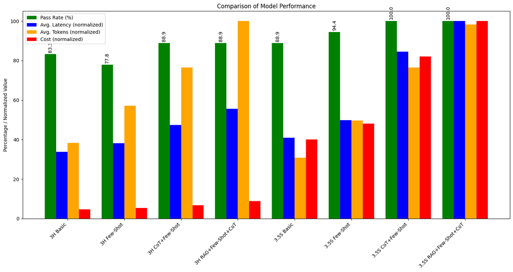

```python
import matplotlib.pyplot as plt
import numpy as np

# Data
models = [
    "3H Basic",
    "3H Few-Shot",
    "3H CoT+Few-Shot",
    "3H RAG+Few-Shot+CoT",
    "3.5S Basic",
    "3.5S Few-Shot",
    "3.5S CoT+Few-Shot",
    "3.5S RAG+Few-Shot+CoT",
]
pass_rates = [83.3, 77.8, 88.9, 88.9, 88.9, 94.4, 100, 100]
avg_latencies = [1561, 1758, 2187, 2564, 1887, 2297, 3900, 4614]
avg_tokens = [383, 572, 765, 1001, 309, 496, 765, 984]
costs = [0.0023, 0.0027, 0.0034, 0.0044, 0.020, 0.024, 0.041, 0.050]

# Normalize the data
max_latency = max(avg_latencies)
max_tokens = max(avg_tokens)
max_cost = max(costs)
norm_latencies = [latency / max_latency * 100 for latency in avg_latencies]
norm_tokens = [t / max_tokens * 100 for t in avg_tokens]
norm_costs = [c / max_cost * 100 for c in costs]

# Set up the plot
x = np.arange(len(models))
width = 0.2

fig, ax = plt.subplots(figsize=(15, 8))

# Create the bars
ax.bar(x - 1.5 * width, pass_rates, width, label="Pass Rate (%)", color="green")
ax.bar(x - 0.5 * width, norm_latencies, width, label="Avg. Latency (normalized)", color="blue")
ax.bar(x + 0.5 * width, norm_tokens, width, label="Avg. Tokens (normalized)", color="orange")
ax.bar(x + 1.5 * width, norm_costs, width, label="Cost (normalized)", color="red")

# Customize the plot
ax.set_ylabel("Percentage / Normalized Value")
ax.set_title("Comparison of Model Performance")
ax.set_xticks(x)
ax.set_xticklabels(models, rotation=45, ha="right")
ax.legend()


# Add value labels on the bars
def add_labels(rects):
    for rect in rects:
        height = rect.get_height()
        ax.annotate(
            f"{height:.1f}",
            xy=(rect.get_x() + rect.get_width() / 2, height),
            xytext=(0, 3),  # 3 points vertical offset
            textcoords="offset points",
            ha="center",
            va="bottom",
            rotation=90,
        )


add_labels(ax.containers[0])  # Only add labels for pass rates

plt.tight_layout()
plt.show()
```

### Promptfoo 실행하기

`promptfoo eval` 명령으로 평가를 실행할 수 있습니다. `promptfoo view` 명령으로 평가 결과를 볼 수 있습니다. 결과가 어떻게 보이는지 미리 살펴보겠습니다:

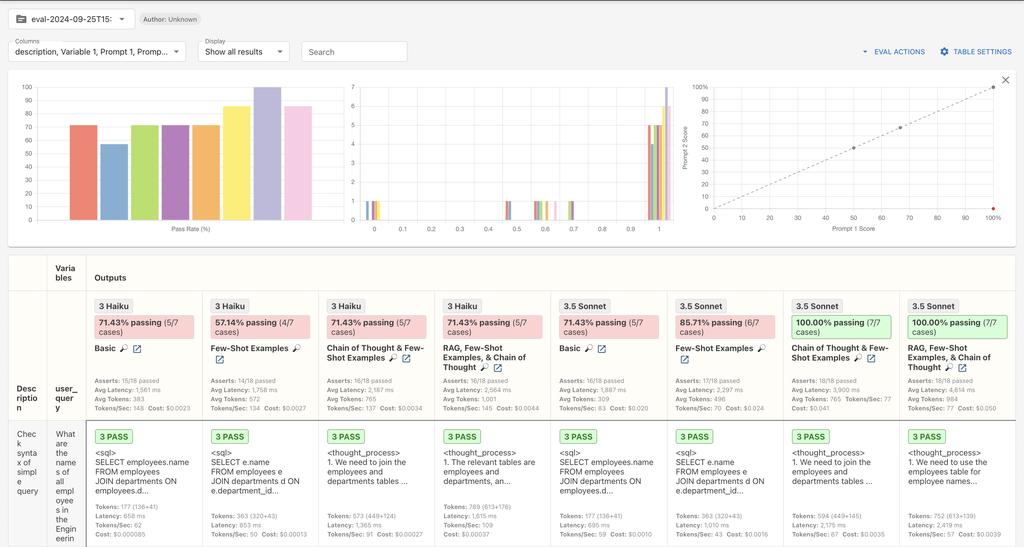

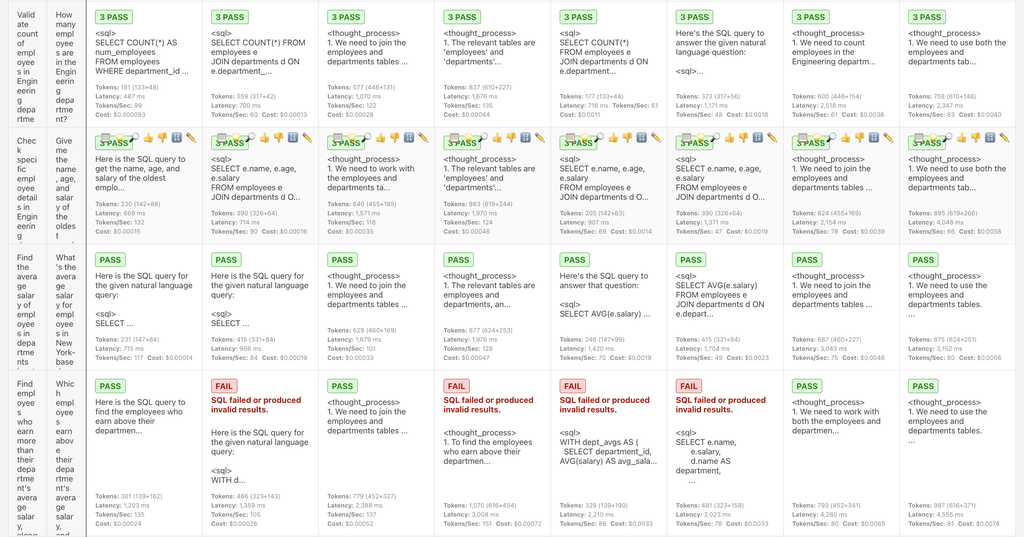

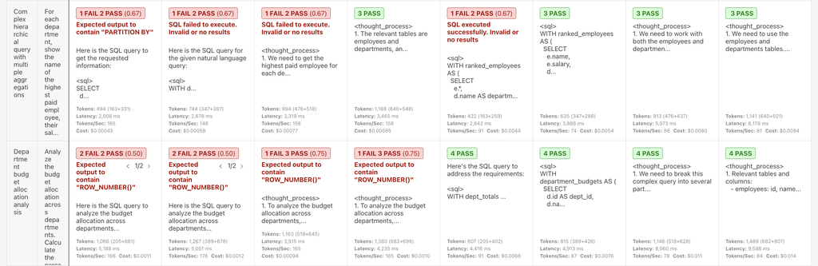

## 더 살펴볼 것과 다음 단계

이 가이드는 Claude로 Text-to-SQL 시스템을 만드는 기초를 다뤘습니다. 해결책을 개선하는 데 도움이 될 만한 방향을 몇 가지 소개합니다.

### 검색 성능 다듬기

데이터베이스가 커질수록 RAG 시스템이 가장 관련성 높고 최신인 정보를 찾도록 하는 것이 중요합니다.

1. **최근 사용 필터**: 일정 기간 안에 일정 횟수 이상 질의된 테이블만 RAG 조회에 포함해, 활발히 관리되는 최신 데이터에 집중하세요.
2. **질의 빈도 순위**: 프로덕션에서 테이블이 얼마나 자주 질의되는지에 따라 RAG 결과의 순위를 매겨, 더 흔히 쓰이는 데이터를 우선하세요.
3. **주기적 갱신**: 스키마가 바뀔 때 벡터 데이터베이스를 갱신하는 체계를 마련해 데이터베이스와 동기화된 상태를 유지하세요.
4. **맥락을 반영한 임베딩**: 테이블 이름과 함께 테이블 간 관계와 사용 패턴도 임베딩해 검색 관련성을 높여 보세요.

### 프롬프트에 맥락 더하기

데이터베이스 스키마에 더해 데이터 구조와 내용에 대한 정보를 프롬프트에서 더 주면 Claude가 더 나은 질의를 생성하는 데 도움이 됩니다.

1. **데이터 표본**: 관련 테이블마다 실제 데이터 몇 행을 프롬프트에 넣으세요. 예를 들면:

```
<data_sample>
Sample data for employees table:
id | name         | age | department_id | salary  | hire_date
1  | John Doe     | 35  | 2             | 75000.0 | 2020-01-15
2  | Jane Smith   | 28  | 3             | 65000.0 | 2021-03-01
</data_sample>
```

2. **열 통계**: 각 열에 대한 유용한 사실을 추가하세요. 예를 들면:
   - 빈 값의 비율
   - 숫자 열의 최솟값과 최댓값
   - 범주 열에서 가장 흔한 값
3. **데이터 품질 메모**: 특정 열이나 테이블의 알려진 문제나 특수한 경우를 언급하세요.
4. **데이터 카탈로그 정보**: dbt 같은 도구로 데이터를 관리한다면 데이터 카탈로그의 관련 정보를 포함하세요.
   - dbt .yml 파일의 테이블 개요
   - 계산식이나 비즈니스 규칙을 포함한 열 설명
   - 테이블 간 관계와 데이터 계보
   - 데이터 품질 검사와 기대치
   - 시간에 민감한 질의를 위한 갱신 주기
5. **비즈니스 맥락**: 조직에서 데이터가 어떻게 쓰이는지, 흔히 수행하는 분석 유형은 무엇인지, 데이터에서 도출되는 중요한 비즈니스 지표는 무엇인지 등의 정보를 추가하세요.